# 1. Formulate your questions

[Shell Commands](https://rcc-uchicago.github.io/shell-intro/reference/)

```python
#a bunch of crap that downloads and unzips the files for the statemap
import os
import geopandas as gpd

!wget -O cb_2018_us_state_20m.zip https://github.com/jcraw005/DS2500Data/raw/main/cb_2018_us_state_20m.zip
!unzip -o cb_2018_us_state_20m.zip -d state_shapefile
gdf_states = gpd.read_file("state_shapefile/cb_2018_us_state_20m.shp")
```

[output not shown]

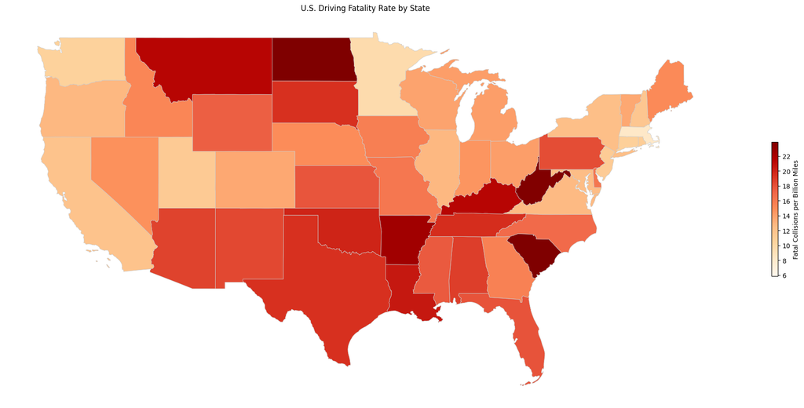

```python
merged = gdf_states.merge(df, left_on="NAME", right_on="state")

merged = merged.drop(index = merged[merged['NAME'] == 'Alaska'].index)
merged = merged.drop(index = merged[merged['NAME'] == 'Hawaii'].index)

fig, ax = plt.subplots(1, 1, figsize=(20, 12))
merged.plot(
    column='number_of_drivers_involved_in_fatal_collisions_per_billion_miles',
    cmap='OrRd',
    linewidth=0.6,
    edgecolor='0.8',
    legend=True,
    ax=ax,
    legend_kwds={'label': "Fatal Collisions per Billion Miles", 'shrink': 0.25}
)
ax.set_title("U.S. Driving Fatality Rate by State")
ax.axis('off')
plt.tight_layout()
plt.show()
```

I for the life of me cannot figure out how to get rid of the Aleutian islands to not make the map rediculusly large, so I just plotted the contiguious US

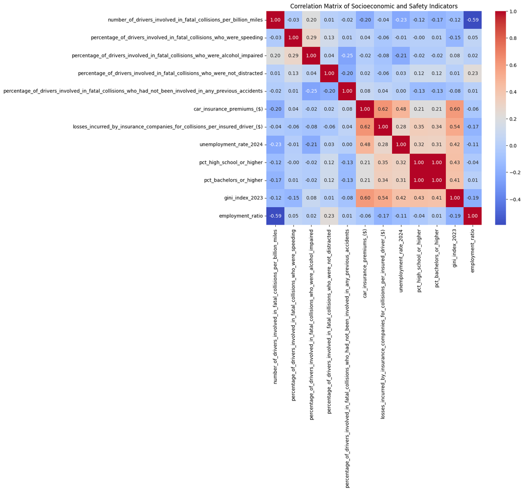

```python
plt.figure(figsize=(10, 8))
sns.heatmap(df.corr(numeric_only=True), annot=True, cmap="coolwarm", fmt=".2f")
plt.title("Correlation Matrix of Socioeconomic and Safety Indicators")

plt.show()
```

# 8. Try an easy solution

```python
stat, p = shapiro(df['number_of_drivers_involved_in_fatal_collisions_per_billion_miles'])
print(f"Shapiro-Wilk test statistic = {stat:.4f}, p-value = {p:.4f}")
```

```
Shapiro-Wilk test statistic = 0.9867, p-value = 0.8354
```

Because we observe a very high p value from the nshapiro test, we can conclude that the number of fatalities (our dependent variable) is normally distributed.

```python
model_edu = ols("number_of_drivers_involved_in_fatal_collisions_per_billion_miles ~ "
    "pct_high_school_or_higher + "
    "pct_bachelors_or_higher",
    data=df).fit()
anova_edu = anova_lm(model_edu)
print("Education ANOVA")
print(anova_edu)
```

```
Education ANOVA
                             df      sum_sq     mean_sq          F    PR(>F)
pct_high_school_or_higher   1.0   11.994685   11.994685   1.016182  0.318481
pct_bachelors_or_higher     1.0  270.973772  270.973772  22.956720  0.000016
Residual                   48.0  566.576641   11.803680        NaN       NaN
```

```python
beh_df = df.copy()
model_beh = ols(
    "number_of_drivers_involved_in_fatal_collisions_per_billion_miles ~ "
    "unemployment_rate_2024 + "
    "gini_index_2023 + "
    "employment_ratio",
    data=beh_df).fit()
anova_beh = anova_lm(model_beh)
print("Behavior ANOVA")
print(anova_beh)
```

```
Behavior ANOVA
                          df      sum_sq     mean_sq          F        PR(>F)
unemployment_rate_2024   1.0   44.849556   44.849556   4.562241  3.792324e-02
gini_index_2023          1.0    0.680746    0.680746   0.069248  7.935856e-01
employment_ratio         1.0  341.976731  341.976731  34.786974  3.838531e-07
Residual                47.0  462.038065    9.830597        NaN           NaN
```

```python
df.head()
model_econ = ols("number_of_drivers_involved_in_fatal_collisions_per_billion_miles ~ gini_index_2023 + employment_ratio + unemployment_rate_2024", data=df).fit()
anova_econ = anova_lm(model_econ)
print("Economic ANOVA")
print(anova_econ)
```

```
Economic ANOVA
                          df      sum_sq     mean_sq          F        PR(>F)
gini_index_2023          1.0   12.748412   12.748412   1.296810  2.605680e-01
employment_ratio         1.0  333.647845  333.647845  33.939733  4.934788e-07
unemployment_rate_2024   1.0   41.110775   41.110775   4.181920  4.647943e-02
Residual                47.0  462.038065    9.830597        NaN           NaN
```

```python
ovr_df = df.copy()
ovr_df.rename(columns={
    'percentage_of_drivers_involved_in_fatal_collisions_who_were_alcohol_impaired' : 'alcohol_impared',
    'percentage_of_drivers_involved_in_fatal_collisions_who_were_not_distracted' : 'distracted',
    'percentage_of_drivers_involved_in_fatal_collisions_who_were_speeding' : 'speeding',
    'percentage_of_drivers_involved_in_fatal_collisions_who_had_not_been_involved_in_any_previous_accidents' : 'prev_accidents',
    'car_insurance_premiums_($)' : 'insureance_prem',
    'losses_incurred_by_insurance_companies_for_collisions_per_insured_driver_($)' : 'insurance_losses'
}, inplace = True)


model_ovr = ols(
    "number_of_drivers_involved_in_fatal_collisions_per_billion_miles ~"
    "alcohol_impared + "
    "distracted + "
    "speeding + "
    "prev_accidents + "
    "insureance_prem + "
    "insurance_losses + "
    "unemployment_rate_2024 + "
    "pct_high_school_or_higher + "
    "pct_bachelors_or_higher + "
    "gini_index_2023 + "
    "employment_ratio",
    data=ovr_df).fit()
anova_ovr = anova_lm(model_ovr)
print("All Variables - ANOVA")
print(anova_ovr)
```

```
All Variables - ANOVA
                             df      sum_sq     mean_sq          F    PR(>F)
alcohol_impared             1.0   33.787145   33.787145   3.716102  0.061195
distracted                  1.0    0.001088    0.001088   0.000120  0.991327
speeding                    1.0    7.000598    7.000598   0.769965  0.385601
prev_accidents              1.0    1.628584    1.628584   0.179121  0.674455
insureance_prem             1.0   32.633822   32.633822   3.589253  0.065587
insurance_losses            1.0   14.161937   14.161937   1.557610  0.219457
unemployment_rate_2024      1.0    8.055210    8.055210   0.885958  0.352369
pct_high_school_or_higher   1.0    7.253227    7.253227   0.797751  0.377245
pct_bachelors_or_higher     1.0  252.002497  252.002497  27.716664  0.000005
gini_index_2023             1.0    6.437519    6.437519   0.708035  0.405227
employment_ratio            1.0  131.991825  131.991825  14.517209  0.000481
Residual                   39.0  354.591646    9.092093        NaN       NaN
```

```python
df_numeric = df.select_dtypes(include='number')
X_all = df_numeric.drop(columns=[
    'number_of_drivers_involved_in_fatal_collisions_per_billion_miles'
    ], errors='ignore')
X_all = sm.add_constant(X_all)
y_all = df_numeric['number_of_drivers_involved_in_fatal_collisions_per_billion_miles']

model_all = sm.OLS(y_all, X_all).fit()
print(model_all.summary())
```

```
                                                   OLS Regression Results
============================================================================================================================
Dep. Variable:     number_of_drivers_involved_in_fatal_collisions_per_billion_miles   R-squared:                       0.583
Model:                                                                          OLS   Adj. R-squared:                  0.465
Method:                                                               Least Squares   F-statistic:                     4.949
Date:                                                              Tue, 19 Aug 2025   Prob (F-statistic):           9.05e-05
Time:                                                                      16:45:55   Log-Likelihood:                -121.81
No. Observations:                                                                51   AIC:                             267.6
Df Residuals:                                                                    39   BIC:                             290.8
Df Model:                                                                        11
Covariance Type:                                                          nonrobust
==========================================================================================================================================================================
                                                                                                             coef    std err          t      P>|t|      [0.025      0.975]
--------------------------------------------------------------------------------------------------------------------------------------------------------------------------
const                                                                                                     70.0172     19.836      3.530      0.001      29.895     110.140
percentage_of_drivers_involved_in_fatal_collisions_who_were_speeding                                      -0.0435      0.049     -0.886      0.381      -0.143       0.056
percentage_of_drivers_involved_in_fatal_collisions_who_were_alcohol_impaired                               0.1779      0.097      1.842      0.073      -0.017       0.373
percentage_of_drivers_involved_in_fatal_collisions_who_were_not_distracted                                 0.0409      0.031      1.326      0.193      -0.021       0.103
percentage_of_drivers_involved_in_fatal_collisions_who_had_not_been_involved_in_any_previous_accidents     0.0250      0.067      0.376      0.709      -0.110       0.160
car_insurance_premiums_($)                                                                                -0.0006      0.004     -0.164      0.871      -0.008       0.007
losses_incurred_by_insurance_companies_for_collisions_per_insured_driver_($)                               0.0060      0.025      0.243      0.810      -0.044       0.056
unemployment_rate_2024                                                                                    -0.8834      0.650     -1.360      0.182      -2.197       0.431
pct_high_school_or_higher                                                                               2.392e-06   1.19e-06      2.015      0.051   -9.28e-09    4.79e-06
pct_bachelors_or_higher                                                                                -1.076e-05   5.26e-06     -2.047      0.047   -2.14e-05   -1.26e-07
gini_index_2023                                                                                          -47.2565     35.338     -1.337      0.189    -118.735      24.222
employment_ratio                                                                                          -0.6092      0.160     -3.810      0.000      -0.933      -0.286
==============================================================================
Omnibus:                        2.193   Durbin-Watson:                   1.824
Prob(Omnibus):                  0.334   Jarque-Bera (JB):                2.063
Skew:                           0.471   Prob(JB):                        0.357
Kurtosis:                       2.710   Cond. No.                     6.45e+08
==============================================================================

Notes:
[1] Standard Errors assume that the covariance matrix of the errors is correctly specified.
[2] The condition number is large, 6.45e+08. This might indicate that there are
strong multicollinearity or other numerical problems.
```

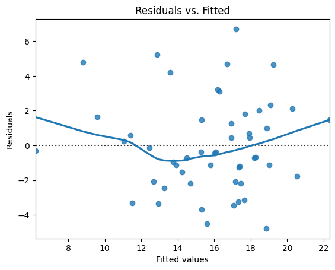

```python
residuals = model_all.resid
fitted = model_all.fittedvalues

sns.residplot(x=fitted, y=residuals, lowess=True)
plt.xlabel("Fitted values")
plt.ylabel("Residuals")
plt.title("Residuals vs. Fitted")
plt.show()
```

Lets try with only the significant predictors (using alpha = 0.05)

```python
significant_predictors = model_all.pvalues[model_all.pvalues < 0.05].index
significant_predictors = [col for col in significant_predictors if col != 'const'] #filter out the intercept, as it was sig.
```

```python
X_sig = sm.add_constant(df_numeric[significant_predictors])
model_sig = sm.OLS(y_all, X_sig).fit()
print(model_sig.summary())
```

```
                                                   OLS Regression Results
============================================================================================================================
Dep. Variable:     number_of_drivers_involved_in_fatal_collisions_per_billion_miles   R-squared:                       0.376
Model:                                                                          OLS   Adj. R-squared:                  0.350
Method:                                                               Least Squares   F-statistic:                     14.47
Date:                                                              Tue, 19 Aug 2025   Prob (F-statistic):           1.21e-05
Time:                                                                      16:45:55   Log-Likelihood:                -132.06
No. Observations:                                                                51   AIC:                             270.1
Df Residuals:                                                                    48   BIC:                             275.9
Df Model:                                                                         2
Covariance Type:                                                          nonrobust
===========================================================================================
                              coef    std err          t      P>|t|      [0.025      0.975]
-------------------------------------------------------------------------------------------
const                      60.5144      8.560      7.070      0.000      43.304      77.725
pct_bachelors_or_higher -5.839e-07   4.07e-07     -1.434      0.158    -1.4e-06    2.35e-07
employment_ratio           -0.6900      0.134     -5.168      0.000      -0.958      -0.422
==============================================================================
Omnibus:                       12.706   Durbin-Watson:                   1.687
Prob(Omnibus):                  0.002   Jarque-Bera (JB):               13.733
Skew:                           1.010   Prob(JB):                      0.00104
Kurtosis:                       4.544   Cond. No.                     2.78e+07
==============================================================================

Notes:
[1] Standard Errors assume that the covariance matrix of the errors is correctly specified.
[2] The condition number is large, 2.78e+07. This might indicate that there are
strong multicollinearity or other numerical problems.
```

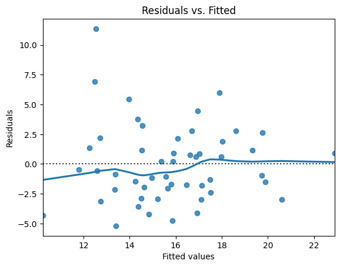

```python
residuals = model_sig.resid
fitted = model_sig.fittedvalues

sns.residplot(x=fitted, y=residuals, lowess=True)
plt.xlabel("Fitted values")
plt.ylabel("Residuals")
plt.title("Residuals vs. Fitted")
plt.show()
```

Both the R^2 and adj R^2 dropped, meaning the model does not fit as well as the orginal. Lets try upping the apha to 0.1, (90% CI)

```python
significant_predictors = model_all.pvalues[model_all.pvalues < 0.1].index
significant_predictors = [col for col in significant_predictors if col != 'const'] #filter out the intercept, as it was sig.
```

```python
X_sig = sm.add_constant(df_numeric[significant_predictors])
model_sig = sm.OLS(y_all, X_sig).fit()
print(model_sig.summary())
```

```
                                                   OLS Regression Results
============================================================================================================================
Dep. Variable:     number_of_drivers_involved_in_fatal_collisions_per_billion_miles   R-squared:                       0.480
Model:                                                                          OLS   Adj. R-squared:                  0.435
Method:                                                               Least Squares   F-statistic:                     10.63
Date:                                                              Tue, 19 Aug 2025   Prob (F-statistic):           3.49e-06
Time:                                                                      16:45:56   Log-Likelihood:                -127.40
No. Observations:                                                                51   AIC:                             264.8
Df Residuals:                                                                    46   BIC:                             274.5
Df Model:                                                                         4
Covariance Type:                                                          nonrobust
================================================================================================================================================
                                                                                   coef    std err          t      P>|t|      [0.025      0.975]
------------------------------------------------------------------------------------------------------------------------------------------------
const                                                                           42.1379     10.198      4.132      0.000      21.611      62.665
percentage_of_drivers_involved_in_fatal_collisions_who_were_alcohol_impaired     0.1606      0.085      1.879      0.067      -0.011       0.333
pct_high_school_or_higher                                                     2.661e-06   1.15e-06      2.315      0.025    3.47e-07    4.98e-06
pct_bachelors_or_higher                                                       -1.24e-05   5.13e-06     -2.419      0.020   -2.27e-05   -2.08e-06
employment_ratio                                                                -0.4858      0.154     -3.155      0.003      -0.796      -0.176
==============================================================================
Omnibus:                        1.825   Durbin-Watson:                   1.964
Prob(Omnibus):                  0.402   Jarque-Bera (JB):                1.225
Skew:                           0.372   Prob(JB):                        0.542
Kurtosis:                       3.150   Cond. No.                     1.64e+08
==============================================================================

Notes:
[1] Standard Errors assume that the covariance matrix of the errors is correctly specified.
[2] The condition number is large, 1.64e+08. This might indicate that there are
strong multicollinearity or other numerical problems.
```

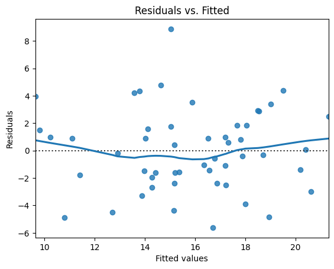

```python
residuals = model_sig.resid
fitted = model_sig.fittedvalues

sns.residplot(x=fitted, y=residuals, lowess=True)
plt.xlabel("Fitted values")
plt.ylabel("Residuals")
plt.title("Residuals vs. Fitted")
plt.show()
```

```python
ovr_df = df.select_dtypes(include='number')
ovr_df.rename(columns={
    'percentage_of_drivers_involved_in_fatal_collisions_who_were_alcohol_impaired' : 'alcohol_impared',
    'percentage_of_drivers_involved_in_fatal_collisions_who_were_not_distracted' : 'distracted',
    'percentage_of_drivers_involved_in_fatal_collisions_who_were_speeding' : 'speeding',
    'percentage_of_drivers_involved_in_fatal_collisions_who_had_not_been_involved_in_any_previous_accidents' : 'prev_accidents',
    'car_insurance_premiums_($)' : 'insureance_prem',
    'losses_incurred_by_insurance_companies_for_collisions_per_insured_driver_($)' : 'insurance_losses'
}, inplace = True)


X_all = ovr_df.drop(columns=[
    'number_of_drivers_involved_in_fatal_collisions_per_billion_miles',
    'pct_bachelors_or_higher',
    'insurance_losses',
    'unemployment_rate_2024',
    'gini_index_2023',

    ], errors='ignore')
X_all = sm.add_constant(X_all)
y_all = ovr_df['number_of_drivers_involved_in_fatal_collisions_per_billion_miles']

model_all = sm.OLS(y_all, X_all).fit()
print(model_all.summary())
```

```
                                                   OLS Regression Results
============================================================================================================================
Dep. Variable:     number_of_drivers_involved_in_fatal_collisions_per_billion_miles   R-squared:                       0.495
Model:                                                                          OLS   Adj. R-squared:                  0.413
Method:                                                               Least Squares   F-statistic:                     6.016
Date:                                                              Tue, 19 Aug 2025   Prob (F-statistic):           6.37e-05
Time:                                                                      16:45:56   Log-Likelihood:                -126.68
No. Observations:                                                                51   AIC:                             269.4
Df Residuals:                                                                    43   BIC:                             284.8
Df Model:                                                                         7
Covariance Type:                                                          nonrobust
=============================================================================================
                                coef    std err          t      P>|t|      [0.025      0.975]
---------------------------------------------------------------------------------------------
const                        55.5048     11.115      4.994      0.000      33.090      77.920
speeding                     -0.0370      0.049     -0.753      0.456      -0.136       0.062
alcohol_impared               0.1978      0.094      2.096      0.042       0.008       0.388
distracted                    0.0527      0.031      1.679      0.100      -0.011       0.116
prev_accidents                0.0530      0.069      0.770      0.445      -0.086       0.192
insureance_prem              -0.0050      0.003     -1.940      0.059      -0.010       0.000
pct_high_school_or_higher -8.723e-08   9.03e-08     -0.966      0.340   -2.69e-07    9.49e-08
employment_ratio             -0.7660      0.131     -5.845      0.000      -1.030      -0.502
==============================================================================
Omnibus:                        2.743   Durbin-Watson:                   1.804
Prob(Omnibus):                  0.254   Jarque-Bera (JB):                2.456
Skew:                           0.531   Prob(JB):                        0.293
Kurtosis:                       2.836   Cond. No.                     1.72e+08
==============================================================================

Notes:
[1] Standard Errors assume that the covariance matrix of the errors is correctly specified.
[2] The condition number is large, 1.72e+08. This might indicate that there are
strong multicollinearity or other numerical problems.
```